# Week 4: review – Hands-on

Prof. Dario Gregori – Dott. Corrado Lanera – Dott. Slavica Zec

# Outline

- Preamble
  - Aims
  - Algorithms
  - Packages
  - Data used
- Analyses
  - data splitting and preparation
  - training/validation/selection models
    - LASSO
    - Ridge
    - Elastic network
    - CART
    - Conditional tree
    - Random Forest
    - Random Forest with Boruta variable selection
  - Boruta variable importance
- Comparisons
- Links

# Preamble

## Aims

The purpose of this hands-on is to:

1. Review the main functions and procedures introducted in the past weeks
2. Perform a Machine Learning task through different models
3. Compare ad discuss the results obtained

To achieve these objectives, we use a real data set (that has been manipulated in order to be anonymized), that comprises clinical information with the aim to model a functional status score based on “Lifestyle”, “Symptoms”, and other functional information provided.

## Algorithms

The algorithms considered will be the ones introducted in the past weeks: lasso, ridge, elastic net, cart, random forest and, finally, random forest comined with Boruta (which will select (within cross-validation steps) the variables for one extra random forest model.

All the algorithm will be run on a set of full data (no missing data present). In particular, we will use 90% of the data as training/validation subset and the other 10% of them as testing one. The train strategy is to select the simplest 10-folds cross-validated trained model within one standard error of the empirically optimal model (Breiman et al. (1984)), using Root Mean Squared Error as a criteria.

All the algorithms will be run (trained, validated and tested) using the `caret` common interface. For the parametric algorithm (i.e. lasso, ridge and elastic net) we have to *dummify* the categorical variable and, in particular, we will change the ordinal variables into cardinal ones. Furthermore, before the parametric algorithms, we perform centering (around the mean) and scaling (by standard deviation) of all the continuous data, to avoid magnitude issues. For the non parametric algorithms, i.e. the tree based ones: cart, ctree, random forest and Boruta, we do not need to perform neither the dummification nor the centering and re-scaling of the data.

## Packages

For the purpose of this hands-on we are going to load the `caret` package, which is the only one truly needed. The package `Boruta` will be loaded to perform and plot the overall variable importance, used only as a benchmark for the selection made by the other algorithms. The `tidyverse` package will be used and useful for data management while the `stringr` one will be loaded as a tool to manage strings (we will use it to manage the names of the categorical variables converted into dummies). Finally, we will introduce the `pryr` package which is an incredible powerful tool to take a look *inside* the R structure and functionality, e.g. we will use it to show the maximum (difference in the) amount of RAM we need to perform each one of the training algorithms. Following what we have done in each hands-on, we use the package `pacman` to install and load the selected package in an efficient way.

```
train(x, y,

    ## model to use
    #
    method     = "rf",

    ## string vector for pre-processing of the data
    #
    preProcess = NULL,

    ## summary metric to be used to select the optimal model.
    #
    metric     = ifelse(is.factor(y), "Accuracy", "RMSE"),

    ## should the metric be maximized (or minimized)?
    #
    maximize   = ifelse(metric %in% c("RMSE", "logLoss"), FALSE, TRUE),


    ## how the function acts
    #
    trControl  = trainControl(

        method            = 'boot',
        number            = ifelse(grepl("cv", method), 10, 25),
        repeats           = ,
        search            = "grid",
        savePredictions   = FALSE,
        selectionFunction = "best",
        seeds             = NA,
        [...]
    ),

    ## a data frame with possible tuning values.
    ## Suggestion: use `expand.grind()`
    #
    tuneGrid   = NULL,

    ## amount of granularity in the tuning parameter grid.
    #
    tuneLength = 3,

    ## Other explicit parameters
    #
    [...],

    ## Other implicit parameters
    #
    ...
)
```

## Data used

First load and take a look to the data provided

```r
load('datafake_w4.rda')
datafake_w4 <- datafake_w4 %>%
    ## put the outcome at the first position for coding convenience
    #
    dplyr::select(outcome, everything()) %>%

    ## transform ordinal factors
    #
    mutate(
        symptom_2 = factor(symptom_2,
                levels  = c('none', 'one', 'both'),
                ordered = TRUE
        )
)
## check for no missing data anywhere, as expected:
#
# map_int(datafake_w4, ~ is.na(.) %>% sum)
#
datafake_w4
```

| outcome | age | allergy_1 | allergy_2 | bmi | collin_bmi | collin_symptom_11 | collin_symptom_11_12 | height | hemodynamic_1 | hemodynamic_2 | hemodynamic_3 | history_1 | history_2 | lifestyle_1 | lifestyle_2 | lifestyle_3 | lifestyle_4 | random_bin | random_norm | random_symptom3 | random_unif | sex | symptom_1 | symptom_10 | symptom_11 | symptom_12 | symptom_13 | symptom_14 | symptom_2 | … |
| --- | --- | --- | --- | --- | --- | --- | --- | --- | --- | --- | --- | --- | --- | --- | --- | --- | --- | --- | --- | --- | --- | --- | --- | --- | --- | --- | --- | --- | --- | --- |
| 45.833333 | 69 | N | N | 27.00 | 24.69766 | 2250435.121 | 91.31994 | 173 | 125 | 72 | 80 | N | Y | Y | Y | N | NORMAL | 0 | 91.54845 | 178 | 13.16117527 | M | 6 | Y | 140 | 120 | N | Y | both | … |
| 31.250000 | 64 | N | N | 27.00 | 29.08269 | 2538346.341 | 127.97603 | 168 | 150 | 70 | 90 | N | N | N | N | N | NORMAL | 0 | 123.47911 | 159 | 13.45328393 | M | 8 | Y | 145 | 140 | N | Y | both | … |
| 32.291667 | 50 | Y | N | 26.00 | 27.43929 | 1758020.924 | 178.36937 | 160 | 135 | 68 | 80 | N | N | N | Y | N | NORMAL | 1 | 143.44298 | 150 | 113.29103635 | F | 2 | Y | 150 | 135 | Y | Y | one | … |
| 52.083333 | 56 | N | N | 27.00 | 24.31276 | 495804.639 | 125.14767 | 159 | 150 | 80 | 90 | Y | Y | N | Y | N | ABNORMAL | 0 | 117.40815 | 6 | 69.12808857 | F | 7 | Y | 135 | 130 | Y | Y | both | … |
| 53.125000 | 62 | Y | N | 27.00 | 29.14046 | 307267.381 | 192.62407 | 165 | 140 | 68 | 80 | N | Y | N | N | N | NORMAL | 1 | 111.55740 | 55 | 90.21520381 | F | 30 | Y | 125 | 120 | Y | Y | both | … |
| 9.375000 | 65 | N | N | 26.00 | 27.67095 | 2898353.594 | 240.63105 | 155 | 130 | 72 | 75 | N | Y | N | Y | N | NORMAL | 0 | 92.12283 | 221 | 48.02045280 | F | 10 | Y | 150 | 150 | Y | Y | both | … |
| 37.500000 | 61 | N | N | 23.00 | 25.34523 | 752241.361 | 185.68058 | 168 | 125 | 72 | 60 | N | N | N | Y | N | NORMAL | 0 | 104.81814 | 246 | 127.33015094 | F | 15 | Y | 140 | 130 | Y | Y | one | … |
| 40.625000 | 54 | N | N | 27.00 | 26.00502 | 102318.944 | 163.83655 | 163 | 145 | 68 | 85 | N | N | N | Y | Y | NORMAL | 0 | 128.26807 | 235 | 107.75780895 | F | 8 | Y | 130 | 125 | N | Y | both | … |
| 19.791667 | 66 | N | N | 27.00 | 29.84581 | 2338330.764 | 207.55129 | 166 | 125 | 70 | 70 | N | Y | N | N | N | NORMAL | 0 | 149.41013 | 52 | 114.38166141 | F | 12 | Y | 150 | 150 | Y | Y | one | … |
| 28.125000 | 66 | N | N | 27.00 | 29.95868 | 695657.748 | 110.73378 | 167 | 155 | 70 | 80 | N | Y | N | N | N | NORMAL | 1 | 130.17781 | 101 | 8.40671713 | F | 8 | Y | 90 | 140 | Y | Y | both | … |

[output cut: 247 more lines]

# Analyses

## data preparation and splitting

Now, for the glm algorithms, convert the ordinal and the categorical variables in, respectively, cardinal and dummies.

```r
data_glm <- datafake_w4 %>% mutate(symptom_2 = as.integer(symptom_2))
data_glm <- data_glm %>%
    dummyVars(formula = outcome ~ .,
        data = .,
        sep  = '_'
    ) %>%
    predict(newdata = data_glm) %>%
    as_data_frame %>%
    bind_cols(datafake_w4['outcome'], .)
## check for no other factor variables, as expected:
#
# map_lgl(datafake_w4, is.factor) %>% sum
data_glm
```

| outcome | age | allergy_1_N | allergy_1_Y | allergy_2_N | allergy_2_Y | bmi | collin_bmi | collin_symptom_11 | collin_symptom_11_12 | height | hemodynamic_1 | hemodynamic_2 | hemodynamic_3 | history_1_N | history_1_Y | history_2_N | history_2_Y | lifestyle_1_N | lifestyle_1_Y | lifestyle_2_N | lifestyle_2_Y | lifestyle_3_N | lifestyle_3_Y | lifestyle_4_ABNORMAL | lifestyle_4_NORMAL | random_bin | random_norm | random_symptom3 | random_unif | … |
| --- | --- | --- | --- | --- | --- | --- | --- | --- | --- | --- | --- | --- | --- | --- | --- | --- | --- | --- | --- | --- | --- | --- | --- | --- | --- | --- | --- | --- | --- | --- |
| 45.833333 | 69 | 1 | 0 | 1 | 0 | 27.00 | 24.69766 | 2250435.121 | 91.31994 | 173 | 125 | 72 | 80 | 1 | 0 | 0 | 1 | 0 | 1 | 0 | 1 | 1 | 0 | 0 | 1 | 0 | 91.54845 | 178 | 13.16117527 | … |
| 31.250000 | 64 | 1 | 0 | 1 | 0 | 27.00 | 29.08269 | 2538346.341 | 127.97603 | 168 | 150 | 70 | 90 | 1 | 0 | 1 | 0 | 1 | 0 | 1 | 0 | 1 | 0 | 0 | 1 | 0 | 123.47911 | 159 | 13.45328393 | … |
| 32.291667 | 50 | 0 | 1 | 1 | 0 | 26.00 | 27.43929 | 1758020.924 | 178.36937 | 160 | 135 | 68 | 80 | 1 | 0 | 1 | 0 | 1 | 0 | 0 | 1 | 1 | 0 | 0 | 1 | 1 | 143.44298 | 150 | 113.29103635 | … |
| 52.083333 | 56 | 1 | 0 | 1 | 0 | 27.00 | 24.31276 | 495804.639 | 125.14767 | 159 | 150 | 80 | 90 | 0 | 1 | 0 | 1 | 1 | 0 | 0 | 1 | 1 | 0 | 1 | 0 | 0 | 117.40815 | 6 | 69.12808857 | … |
| 53.125000 | 62 | 0 | 1 | 1 | 0 | 27.00 | 29.14046 | 307267.381 | 192.62407 | 165 | 140 | 68 | 80 | 1 | 0 | 0 | 1 | 1 | 0 | 1 | 0 | 1 | 0 | 0 | 1 | 1 | 111.55740 | 55 | 90.21520381 | … |
| 9.375000 | 65 | 1 | 0 | 1 | 0 | 26.00 | 27.67095 | 2898353.594 | 240.63105 | 155 | 130 | 72 | 75 | 1 | 0 | 0 | 1 | 1 | 0 | 0 | 1 | 1 | 0 | 0 | 1 | 0 | 92.12283 | 221 | 48.02045280 | … |
| 37.500000 | 61 | 1 | 0 | 1 | 0 | 23.00 | 25.34523 | 752241.361 | 185.68058 | 168 | 125 | 72 | 60 | 1 | 0 | 1 | 0 | 1 | 0 | 0 | 1 | 1 | 0 | 0 | 1 | 0 | 104.81814 | 246 | 127.33015094 | … |
| 40.625000 | 54 | 1 | 0 | 1 | 0 | 27.00 | 26.00502 | 102318.944 | 163.83655 | 163 | 145 | 68 | 85 | 1 | 0 | 1 | 0 | 1 | 0 | 0 | 1 | 0 | 1 | 0 | 1 | 0 | 128.26807 | 235 | 107.75780895 | … |
| 19.791667 | 66 | 1 | 0 | 1 | 0 | 27.00 | 29.84581 | 2338330.764 | 207.55129 | 166 | 125 | 70 | 70 | 1 | 0 | 0 | 1 | 1 | 0 | 1 | 0 | 1 | 0 | 0 | 1 | 0 | 149.41013 | 52 | 114.38166141 | … |
| 28.125000 | 66 | 1 | 0 | 1 | 0 | 27.00 | 29.95868 | 695657.748 | 110.73378 | 167 | 155 | 70 | 80 | 1 | 0 | 0 | 1 | 1 | 0 | 1 | 0 | 1 | 0 | 0 | 1 | 1 | 130.17781 | 101 | 8.40671713 | … |

[output cut: 247 more lines]

And next, split the data in training and test set.

```r
set.seed(12345)
train_idx <- createDataPartition(datafake_w4$outcome,
                p = 0.9, list = FALSE
)
## We will convert data_frame in data.frame because `caret` used to assign
## names to the rows, that is in contrast with the philosophy of tidyverse
## which complains with it (through warnings and maybe errors too).
#
(train_tree <- datafake_w4[train_idx, ] %>% as.data.frame)
```

| outcome | age | allergy_1 | allergy_2 | bmi | collin_bmi | collin_symptom_11 | collin_symptom_11_12 | height | hemodynamic_1 | hemodynamic_2 | hemodynamic_3 | history_1 | history_2 | lifestyle_1 | lifestyle_2 | lifestyle_3 | lifestyle_4 | random_bin | random_norm | random_symptom3 | random_unif | sex | symptom_1 | symptom_10 | symptom_11 | symptom_12 | symptom_13 | symptom_14 | symptom_2 | … |
| --- | --- | --- | --- | --- | --- | --- | --- | --- | --- | --- | --- | --- | --- | --- | --- | --- | --- | --- | --- | --- | --- | --- | --- | --- | --- | --- | --- | --- | --- | --- |
| 45.833333 | 69 | N | N | 27.00 | 24.69766 | 2250435.121 | 91.31994 | 173 | 125 | 72 | 80 | N | Y | Y | Y | N | NORMAL | 0 | 91.54845 | 178 | 13.16117527 | M | 6 | Y | 140 | 120 | N | Y | both | … |
| 31.250000 | 64 | N | N | 27.00 | 29.08269 | 2538346.341 | 127.97603 | 168 | 150 | 70 | 90 | N | N | N | N | N | NORMAL | 0 | 123.47911 | 159 | 13.45328393 | M | 8 | Y | 145 | 140 | N | Y | both | … |
| 52.083333 | 56 | N | N | 27.00 | 24.31276 | 495804.639 | 125.14767 | 159 | 150 | 80 | 90 | Y | Y | N | Y | N | ABNORMAL | 0 | 117.40815 | 6 | 69.12808857 | F | 7 | Y | 135 | 130 | Y | Y | both | … |
| 53.125000 | 62 | Y | N | 27.00 | 29.14046 | 307267.381 | 192.62407 | 165 | 140 | 68 | 80 | N | Y | N | N | N | NORMAL | 1 | 111.55740 | 55 | 90.21520381 | F | 30 | Y | 125 | 120 | Y | Y | both | … |
| 9.375000 | 65 | N | N | 26.00 | 27.67095 | 2898353.594 | 240.63105 | 155 | 130 | 72 | 75 | N | Y | N | Y | N | NORMAL | 0 | 92.12283 | 221 | 48.02045280 | F | 10 | Y | 150 | 150 | Y | Y | both | … |
| 37.500000 | 61 | N | N | 23.00 | 25.34523 | 752241.361 | 185.68058 | 168 | 125 | 72 | 60 | N | N | N | Y | N | NORMAL | 0 | 104.81814 | 246 | 127.33015094 | F | 15 | Y | 140 | 130 | Y | Y | one | … |
| 40.625000 | 54 | N | N | 27.00 | 26.00502 | 102318.944 | 163.83655 | 163 | 145 | 68 | 85 | N | N | N | Y | Y | NORMAL | 0 | 128.26807 | 235 | 107.75780895 | F | 8 | Y | 130 | 125 | N | Y | both | … |
| 19.791667 | 66 | N | N | 27.00 | 29.84581 | 2338330.764 | 207.55129 | 166 | 125 | 70 | 70 | N | Y | N | N | N | NORMAL | 0 | 149.41013 | 52 | 114.38166141 | F | 12 | Y | 150 | 150 | Y | Y | one | … |
| 28.125000 | 66 | N | N | 27.00 | 29.95868 | 695657.748 | 110.73378 | 167 | 155 | 70 | 80 | N | Y | N | N | N | NORMAL | 1 | 130.17781 | 101 | 8.40671713 | F | 8 | Y | 90 | 140 | Y | Y | both | … |
| 55.208333 | 70 | N | N | 27.00 | 27.67556 | 1524866.678 | 136.07522 | 163 | 140 | 84 | 85 | N | Y | N | Y | N | NORMAL | 0 | 154.80757 | 228 | 25.71025263 | F | 15 | Y | 120 | 130 | Y | Y | both | … |

[output cut: 223 more lines]

```r
(test_tree  <- datafake_w4[-train_idx, ] %>% as.data.frame)
```

| outcome | age | allergy_1 | allergy_2 | bmi | collin_bmi | collin_symptom_11 | collin_symptom_11_12 | height | hemodynamic_1 | hemodynamic_2 | hemodynamic_3 | history_1 | history_2 | lifestyle_1 | lifestyle_2 | lifestyle_3 | lifestyle_4 | random_bin | random_norm | random_symptom3 | random_unif | sex | symptom_1 | symptom_10 | symptom_11 | symptom_12 | symptom_13 | symptom_14 | symptom_2 | … |
| --- | --- | --- | --- | --- | --- | --- | --- | --- | --- | --- | --- | --- | --- | --- | --- | --- | --- | --- | --- | --- | --- | --- | --- | --- | --- | --- | --- | --- | --- | --- |
| 32.291667 | 50 | Y | N | 26.00 | 27.43929 | 1758020.924 | 178.36937 | 160 | 135 | 68 | 80 | N | N | N | Y | N | NORMAL | 1 | 143.44298 | 150 | 113.2910363 | F | 2 | Y | 150 | 135 | Y | Y | one | … |
| 45.833333 | 69 | N | N | 28.00 | 25.21729 | 3183110.169 | 91.61581 | 178 | 150 | 64 | 95 | N | Y | Y | N | N | NORMAL | 0 | 77.01608 | 11 | 55.1179880 | M | 30 | Y | 150 | 140 | Y | Y | one | … |
| 8.333333 | 62 | N | N | 27.00 | 27.41290 | 1208550.127 | 65.78308 | 165 | 140 | 72 | 100 | N | N | N | Y | N | NORMAL | 1 | 100.55152 | 108 | 67.2643164 | F | 11 | Y | 130 | 130 | Y | Y | both | … |
| 16.666667 | 64 | N | N | 23.00 | 20.05192 | 2107481.910 | 191.32050 | 164 | 110 | 62 | 60 | N | Y | N | Y | N | NORMAL | 0 | 83.52852 | 15 | 93.6395687 | F | 10 | Y | 150 | 150 | N | Y | both | … |
| 7.291667 | 65 | N | N | 22.00 | 19.51430 | 1442055.362 | 150.78756 | 170 | 135 | 86 | 85 | N | Y | Y | Y | N | NORMAL | 1 | 87.37742 | 117 | 146.3036941 | F | 15 | Y | 145 | 140 | Y | Y | both | … |
| 32.617188 | 66 | N | N | 24.00 | 21.35629 | 609924.881 | 176.95058 | 155 | 150 | 80 | 90 | N | Y | N | Y | N | NORMAL | 1 | 92.55986 | 128 | 0.7248517 | F | 5 | Y | 140 | 130 | Y | Y | one | … |
| 33.333333 | 59 | N | N | 27.00 | 27.33469 | 735621.321 | 204.30963 | 170 | 135 | 90 | 90 | N | N | N | Y | N | NORMAL | 1 | 84.74995 | 127 | 17.8490551 | F | 7 | Y | 140 | 140 | Y | Y | one | … |
| 41.666667 | 73 | N | N | 29.00 | 29.36944 | 355925.958 | 162.13856 | 170 | 160 | 70 | 95 | N | Y | N | N | N | NORMAL | 0 | 129.50383 | 151 | 122.8583943 | F | 20 | Y | 120 | 130 | Y | Y | both | … |
| 23.458333 | 68 | N | N | 27.68 | 25.41768 | 126540.738 | 53.64124 | 170 | 145 | 60 | 80 | N | N | N | Y | N | NORMAL | 0 | 113.97705 | 102 | 46.9281859 | M | 1 | Y | 72 | 68 | Y | Y | both | … |
| 48.958333 | 68 | N | Y | 30.02 | 31.15907 | 7416.090 | 46.32401 | 157 | 135 | 80 | 85 | N | N | N | Y | N | ABNORMAL | 0 | 94.25707 | 218 | 84.5711930 | F | 1 | N | 58 | 68 | N | N | both | … |

[output cut: 14 more lines]

```r
(train_glm <- data_glm[train_idx, ] %>% as.data.frame)
```

| outcome | age | allergy_1_N | allergy_1_Y | allergy_2_N | allergy_2_Y | bmi | collin_bmi | collin_symptom_11 | collin_symptom_11_12 | height | hemodynamic_1 | hemodynamic_2 | hemodynamic_3 | history_1_N | history_1_Y | history_2_N | history_2_Y | lifestyle_1_N | lifestyle_1_Y | lifestyle_2_N | lifestyle_2_Y | lifestyle_3_N | lifestyle_3_Y | lifestyle_4_ABNORMAL | lifestyle_4_NORMAL | random_bin | random_norm | random_symptom3 | random_unif | … |
| --- | --- | --- | --- | --- | --- | --- | --- | --- | --- | --- | --- | --- | --- | --- | --- | --- | --- | --- | --- | --- | --- | --- | --- | --- | --- | --- | --- | --- | --- | --- |
| 45.833333 | 69 | 1 | 0 | 1 | 0 | 27.00 | 24.69766 | 2250435.121 | 91.31994 | 173 | 125 | 72 | 80 | 1 | 0 | 0 | 1 | 0 | 1 | 0 | 1 | 1 | 0 | 0 | 1 | 0 | 91.54845 | 178 | 13.16117527 | … |
| 31.250000 | 64 | 1 | 0 | 1 | 0 | 27.00 | 29.08269 | 2538346.341 | 127.97603 | 168 | 150 | 70 | 90 | 1 | 0 | 1 | 0 | 1 | 0 | 1 | 0 | 1 | 0 | 0 | 1 | 0 | 123.47911 | 159 | 13.45328393 | … |
| 52.083333 | 56 | 1 | 0 | 1 | 0 | 27.00 | 24.31276 | 495804.639 | 125.14767 | 159 | 150 | 80 | 90 | 0 | 1 | 0 | 1 | 1 | 0 | 0 | 1 | 1 | 0 | 1 | 0 | 0 | 117.40815 | 6 | 69.12808857 | … |
| 53.125000 | 62 | 0 | 1 | 1 | 0 | 27.00 | 29.14046 | 307267.381 | 192.62407 | 165 | 140 | 68 | 80 | 1 | 0 | 0 | 1 | 1 | 0 | 1 | 0 | 1 | 0 | 0 | 1 | 1 | 111.55740 | 55 | 90.21520381 | … |
| 9.375000 | 65 | 1 | 0 | 1 | 0 | 26.00 | 27.67095 | 2898353.594 | 240.63105 | 155 | 130 | 72 | 75 | 1 | 0 | 0 | 1 | 1 | 0 | 0 | 1 | 1 | 0 | 0 | 1 | 0 | 92.12283 | 221 | 48.02045280 | … |
| 37.500000 | 61 | 1 | 0 | 1 | 0 | 23.00 | 25.34523 | 752241.361 | 185.68058 | 168 | 125 | 72 | 60 | 1 | 0 | 1 | 0 | 1 | 0 | 0 | 1 | 1 | 0 | 0 | 1 | 0 | 104.81814 | 246 | 127.33015094 | … |
| 40.625000 | 54 | 1 | 0 | 1 | 0 | 27.00 | 26.00502 | 102318.944 | 163.83655 | 163 | 145 | 68 | 85 | 1 | 0 | 1 | 0 | 1 | 0 | 0 | 1 | 0 | 1 | 0 | 1 | 0 | 128.26807 | 235 | 107.75780895 | … |
| 19.791667 | 66 | 1 | 0 | 1 | 0 | 27.00 | 29.84581 | 2338330.764 | 207.55129 | 166 | 125 | 70 | 70 | 1 | 0 | 0 | 1 | 1 | 0 | 1 | 0 | 1 | 0 | 0 | 1 | 0 | 149.41013 | 52 | 114.38166141 | … |
| 28.125000 | 66 | 1 | 0 | 1 | 0 | 27.00 | 29.95868 | 695657.748 | 110.73378 | 167 | 155 | 70 | 80 | 1 | 0 | 0 | 1 | 1 | 0 | 1 | 0 | 1 | 0 | 0 | 1 | 1 | 130.17781 | 101 | 8.40671713 | … |
| 55.208333 | 70 | 1 | 0 | 1 | 0 | 27.00 | 27.67556 | 1524866.678 | 136.07522 | 163 | 140 | 84 | 85 | 1 | 0 | 0 | 1 | 1 | 0 | 0 | 1 | 1 | 0 | 0 | 1 | 0 | 154.80757 | 228 | 25.71025263 | … |

[output cut: 223 more lines]

```r
(test_glm  <- data_glm[-train_idx, ] %>% as.data.frame)
```

| outcome | age | allergy_1_N | allergy_1_Y | allergy_2_N | allergy_2_Y | bmi | collin_bmi | collin_symptom_11 | collin_symptom_11_12 | height | hemodynamic_1 | hemodynamic_2 | hemodynamic_3 | history_1_N | history_1_Y | history_2_N | history_2_Y | lifestyle_1_N | lifestyle_1_Y | lifestyle_2_N | lifestyle_2_Y | lifestyle_3_N | lifestyle_3_Y | lifestyle_4_ABNORMAL | lifestyle_4_NORMAL | random_bin | random_norm | random_symptom3 | random_unif | … |
| --- | --- | --- | --- | --- | --- | --- | --- | --- | --- | --- | --- | --- | --- | --- | --- | --- | --- | --- | --- | --- | --- | --- | --- | --- | --- | --- | --- | --- | --- | --- |
| 32.291667 | 50 | 0 | 1 | 1 | 0 | 26.00 | 27.43929 | 1758020.924 | 178.36937 | 160 | 135 | 68 | 80 | 1 | 0 | 1 | 0 | 1 | 0 | 0 | 1 | 1 | 0 | 0 | 1 | 1 | 143.44298 | 150 | 113.2910363 | … |
| 45.833333 | 69 | 1 | 0 | 1 | 0 | 28.00 | 25.21729 | 3183110.169 | 91.61581 | 178 | 150 | 64 | 95 | 1 | 0 | 0 | 1 | 0 | 1 | 1 | 0 | 1 | 0 | 0 | 1 | 0 | 77.01608 | 11 | 55.1179880 | … |
| 8.333333 | 62 | 1 | 0 | 1 | 0 | 27.00 | 27.41290 | 1208550.127 | 65.78308 | 165 | 140 | 72 | 100 | 1 | 0 | 1 | 0 | 1 | 0 | 0 | 1 | 1 | 0 | 0 | 1 | 1 | 100.55152 | 108 | 67.2643164 | … |
| 16.666667 | 64 | 1 | 0 | 1 | 0 | 23.00 | 20.05192 | 2107481.910 | 191.32050 | 164 | 110 | 62 | 60 | 1 | 0 | 0 | 1 | 1 | 0 | 0 | 1 | 1 | 0 | 0 | 1 | 0 | 83.52852 | 15 | 93.6395687 | … |
| 7.291667 | 65 | 1 | 0 | 1 | 0 | 22.00 | 19.51430 | 1442055.362 | 150.78756 | 170 | 135 | 86 | 85 | 1 | 0 | 0 | 1 | 0 | 1 | 0 | 1 | 1 | 0 | 0 | 1 | 1 | 87.37742 | 117 | 146.3036941 | … |
| 32.617188 | 66 | 1 | 0 | 1 | 0 | 24.00 | 21.35629 | 609924.881 | 176.95058 | 155 | 150 | 80 | 90 | 1 | 0 | 0 | 1 | 1 | 0 | 0 | 1 | 1 | 0 | 0 | 1 | 1 | 92.55986 | 128 | 0.7248517 | … |
| 33.333333 | 59 | 1 | 0 | 1 | 0 | 27.00 | 27.33469 | 735621.321 | 204.30963 | 170 | 135 | 90 | 90 | 1 | 0 | 1 | 0 | 1 | 0 | 0 | 1 | 1 | 0 | 0 | 1 | 1 | 84.74995 | 127 | 17.8490551 | … |
| 41.666667 | 73 | 1 | 0 | 1 | 0 | 29.00 | 29.36944 | 355925.958 | 162.13856 | 170 | 160 | 70 | 95 | 1 | 0 | 0 | 1 | 1 | 0 | 1 | 0 | 1 | 0 | 0 | 1 | 0 | 129.50383 | 151 | 122.8583943 | … |
| 23.458333 | 68 | 1 | 0 | 1 | 0 | 27.68 | 25.41768 | 126540.738 | 53.64124 | 170 | 145 | 60 | 80 | 1 | 0 | 1 | 0 | 1 | 0 | 0 | 1 | 1 | 0 | 0 | 1 | 0 | 113.97705 | 102 | 46.9281859 | … |
| 48.958333 | 68 | 1 | 0 | 0 | 1 | 30.02 | 31.15907 | 7416.090 | 46.32401 | 157 | 135 | 80 | 85 | 1 | 0 | 1 | 0 | 1 | 0 | 0 | 1 | 1 | 0 | 1 | 0 | 0 | 94.25707 | 218 | 84.5711930 | … |

[output cut: 14 more lines]

## training/validation/selection models

First of all, we decide the standard parameter for the training processes, i.e. the number of folds, that is the number of time the cross-validation procedure has to be repeated for each choice of the parameter (to reduce the probability that the solutions found depend on the actual choice of the folds randomly selected only once) and the set of (all different) seeds, one for each step (fold) of the described procedure.

```r
## `gc()` is quite never needed. Here we will use it to reset the
## "max ammount of RAM" used by R. This way, when `pryr::mem_change` access
## to the system information, the difference in the maximum ammount actualy
## spent for the process is only the maximum ammount of memory used.
#
## for reproducibility, we have to set the seeds: `caret` needs a list of
## the (different) seeds to use with each cross-validation step, plus one
## more for to use with the final model selected.
tune_length <- 100
n_folds     <- 10
n_reps      <- 10
caret_seeds <- map(seq_len(n_folds * n_reps + 1),
                   ~ seq(from = tune_length * (. - 1) + 1,
                         to   = tune_length * .,
                         length.out = tune_length)
)
```

### LASSO

Train a LASSO algorithm saves both the time and the RAM cost too

```r
message()
```

```r
message('Elapsed time: ', lasso_time['elapsed'] %>% round(3), ' seconds')
```

```
Elapsed time: 18.85 seconds
```

```r
message('Used memory: ',
        format(lasso_mem/(2^20), digits = 3, scientific = FALSE),
        ' MB')
```

```
Used memory: 6.12 MB
```

```r
lasso_rmse <- (predict(lasso_model, test_glm[-1]) - test_glm[[1]])^2 %>%
    mean %>%
    sqrt
message('Test rmse: ', lasso_rmse)
```

```
Test rmse: 17.0087843461008
```

```r
final_lasso_param <- lasso_model$finalModel$tuneValue
message('Final tuned parameter is: ',
        names(final_lasso_param), ' = ', final_lasso_param %>% round(3)
)
```

```
Final tuned parameter is: fraction = 0.1
```

```r
final_lasso <- lasso_model$finalModel
lasso_best_beta <- predict(final_lasso,
        s    = final_lasso_param[[1]],
        mode = 'fraction',
        type = 'coefficients'
    )$coefficients %>%
    `[`(. != 0) %>%
    round(3) %>%
    sort
message('The variables used by the best (up to one SE) LASSO machine, with
        the corresponding beta values, are:\n',
        paste(lasso_best_beta, names(lasso_best_beta),
              sep = '\t= ',
              collapse = '\n'
        )
)
```

```
The variables used by the best (up to one SE) LASSO machine, with
        the corresponding beta values, are:
-3.046  = collin_symptom_11
-0.938  = symptom_3_N
-0.932  = height
-0.781  = symptom_4_N
0.047   = symptom_7_VALGUS
```

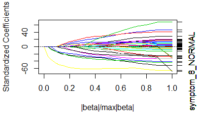

```r
## ?elasticnet:::plot.enet
## c("fraction", "penalty", "L1norm", "step")
#
plot(final_lasso, xvar = 'fraction', use.color = TRUE)
```

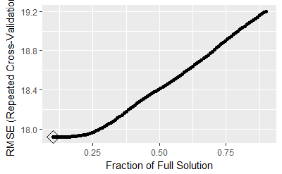

```r
## ?caret:::plot.train
#
ggplot(lasso_model, highlight = TRUE)
```

As we can see, the automatic tuning grid search does not perform at best, i.e. the chosen parameters is on the left border and, in particular it does not seem to identify the minimum. So we have to run again the algorithm considering an explicit grid of tuning parameter (the `fraction`) centered in the region near the minimum identified.

```r
message()
```

```r
message('Elapsed time: ', lasso2_time['elapsed'] %>% round(3), ' seconds')
```

```
Elapsed time: 18.31 seconds
```

```r
message('Used memory: ',
        format(lasso2_mem/(2^20), digits = 3, scientific = FALSE),
        ' MB')
```

```
Used memory: 0.332 MB
```

```r
lasso2_rmse <- (predict(lasso2_model, test_glm[-1]) - test_glm[[1]])^2 %>%
    mean %>%
    sqrt
message('Test rmse: ', lasso2_rmse)
```

```
Test rmse: 17.0637965848834
```

```r
final_lasso2_param <- lasso2_model$finalModel$tuneValue
message('Final tuned parameter is: ',
        names(final_lasso2_param), ' = ', final_lasso2_param %>% round(3)
)
```

```
Final tuned parameter is: fraction = 0.039
```

```r
final_lasso2 <- lasso2_model$finalModel
lasso2_best_beta <- predict(final_lasso2,
        s    = final_lasso2_param[[1]],
        mode = 'fraction',
        type = 'coefficients'
    )$coefficients %>%
    `[`(. != 0) %>%
    round(3)
message('The variables used by the best (up to one SE) LASSO machine, with
        the corresponding beta values, are:\n',
        paste(lasso2_best_beta, names(lasso2_best_beta),
              sep = '\t= ',
              collapse = '\n'
        )
)
```

```
The variables used by the best (up to one SE) LASSO machine, with
        the corresponding beta values, are:
-1.948  = collin_symptom_11
-0.096  = height
-0.181  = symptom_3_N
```

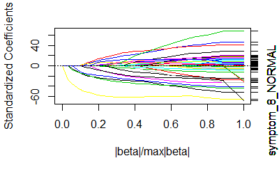

```r
plot(final_lasso2, xvar = 'fraction', use.color = TRUE)
```

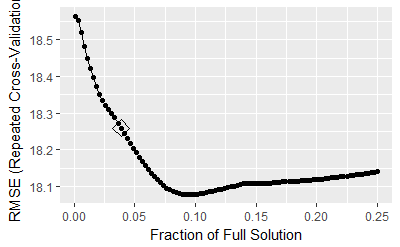

```r
ggplot(lasso2_model, highlight = TRUE)
```

Now the best (up to one SE) parameter selected is both far form the borders and near an evident empirical minimum discovered. So we can be satisfied and retain the corresponding model as the one to select for the LASSO procedure.

### Ridge

```r
message()
```

```r
message('Elapsed time: ', ridge_time['elapsed'] %>% round(3), ' seconds')
```

```
Elapsed time: 711.21 seconds
```

```r
message('Used memory: ',
        format(ridge_mem/(2^20), digits = 3, scientific = FALSE),
        ' MB')
```

```
Used memory: 2 MB
```

```r
ridge_rmse <- (predict(ridge_model, test_glm[-1]) - test_glm[[1]])^2 %>%
    mean %>%
    sqrt
message('Test rmse: ', ridge_rmse)
```

```
Test rmse: 16.4385344328289
```

```r
final_ridge_param <- ridge_model$finalModel$tuneValue
message('Final tuned parameter is: ',
        names(final_ridge_param), ' = ', final_ridge_param %>% round(3)
)
```

```
Final tuned parameter is: lambda = 0.1
```

```r
final_ridge <- ridge_model$finalModel
ridge_best_beta <- predict(final_ridge,
        s    = final_ridge_param[[1]],
        mode = 'fraction',
        type = 'coefficients'
    )$coefficients %>%
    `[`(. != 0) %>%
    round(3)
message('The variables used by the best (up to one SE) ridge machine, with
        the corresponding beta values, are:\n',
        paste(ridge_best_beta, names(ridge_best_beta),
              sep = '\t= ',
              collapse = '\n'
        )
)
```

```
The variables used by the best (up to one SE) ridge machine, with
        the corresponding beta values, are:
-2.696  = collin_symptom_11
-0.775  = height
-0.43   = symptom_3_N
0.43    = symptom_3_Y
-0.207  = symptom_4_N
0.207   = symptom_4_Y
```

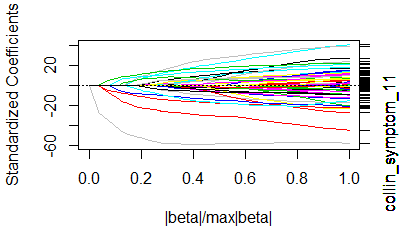

```r
plot(final_ridge, xvar = 'fraction', use.color = TRUE)
```

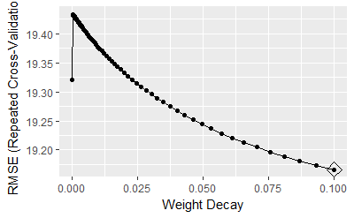

```r
ggplot(ridge_model, highlight = TRUE)
```

Here the parameter selected by the `caret` automatic search grid seams to be unefficent too: the parameter selected is on the right border and it seams that there were some issues on the left one (maybe an extreme value was considered). So re-run the algorithm within a range of values (approximately) cantered around the one selected and with borders likely to contain a minimum value (note that the curve try to go flat so we can expected that a minimum is not so far from the value selected).

```r
message()
```

```r
message('Elapsed time: ', ridge2_time['elapsed'] %>% round(3), ' seconds')
```

```
Elapsed time: 700.56 seconds
```

```r
message('Used memory: ',
        format(ridge2_mem/(2^20), digits = 3, scientific = FALSE),
        ' MB')
```

```
Used memory: 0.309 MB
```

```r
ridge2_rmse <- (predict(ridge2_model, test_glm[-1]) - test_glm[[1]])^2 %>%
    mean %>%
    sqrt
message('Test rmse: ', ridge2_rmse)
```

```
Test rmse: 16.8071938017479
```

```r
final_ridge2_param <- ridge2_model$finalModel$tuneValue
message('Final tuned parameters are: ',
        names(final_ridge2_param), ' = ', final_ridge2_param %>% round(3)
)
```

```
Final tuned parameters are: lambda = 0.624
```

```r
final_ridge2 <- ridge2_model$finalModel
ridge2_best_beta <- predict(final_ridge2,
        s    = final_ridge2_param[[1]],
        mode = 'fraction',
        type = 'coefficients'
    )$coefficients %>%
    `[`(. != 0) %>%
    round(3)
message('The variables used by the best (up to one SE) ridge machine, with
        the corresponding beta values, are:\n',
        paste(ridge2_best_beta, names(ridge2_best_beta),
              sep = '\t= ',
              collapse = '\n'
        )
)
```

```
The variables used by the best (up to one SE) ridge machine, with
        the corresponding beta values, are:
-0.564  = allergy_2_N
0.564   = allergy_2_Y
0.752   = bmi
0.587   = collin_bmi
-3.257  = collin_symptom_11
-0.486  = collin_symptom_11_12
-2.201  = height
0.047   = hemodynamic_2
1.499   = hemodynamic_3
-0.258  = history_1_N
0.258   = history_1_Y
-0.902  = history_2_N
0.902   = history_2_Y
0.079   = lifestyle_1_N
-0.079  = lifestyle_1_Y
-0.573  = lifestyle_3_N
0.573   = lifestyle_3_Y
0.077   = lifestyle_4_ABNORMAL
-0.077  = lifestyle_4_NORMAL
-0.14   = random_norm
0.67    = random_unif
1.791   = symptom_1
0.675   = symptom_10_N
-0.675  = symptom_10_Y
-0.851  = symptom_11
-0.565  = symptom_12
-0.374  = symptom_14_N
0.374   = symptom_14_Y
-1.496  = symptom_3_N
1.496   = symptom_3_Y
-1.222  = symptom_4_N
1.222   = symptom_4_Y
0.489   = symptom_6_N
-0.489  = symptom_6_Y
-0.363  = symptom_7_NORMAL
0.57    = symptom_7_VALGUS
-0.983  = symptom_8_NORMAL
0.638   = symptom_8_VALGUS
0.619   = symptom_9_N
-0.619  = symptom_9_Y
```

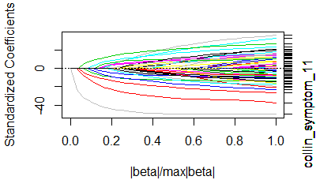

```r
plot(final_ridge2, xvar = 'fraction', use.color = TRUE)
```

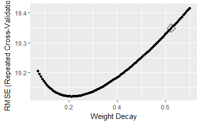

```r
ggplot(ridge2_model, highlight = TRUE)
```

### Elastic network

```r
message()
```

```r
message('Elapsed time: ', enet_time['elapsed'] %>% round(3), ' seconds')
```

```
Elapsed time: 95.16 seconds
```

```r
message('Used memory: ',
        format(enet_mem/(2^20), digits = 3, scientific = FALSE),
        ' MB')
```

```
Used memory: 0.38 MB
```

```r
enet_rmse <- (predict(enet_model, test_glm[-1]) - test_glm[[1]])^2 %>%
    mean %>%
    sqrt
message('Test rmse: ', enet_rmse)
```

```
Test rmse: 16.925395019832
```

```r
final_enet_param <- enet_model$finalModel$tuneValue
message('Final tuned parameter is: ',
        names(final_enet_param)[[1]], ' = ',
        final_enet_param[[1]] %>% round(3),
        '\n',
        names(final_enet_param)[[2]], ' = ',
        final_enet_param[[2]] %>% round(3)
)
```

```
Final tuned parameter is: fraction = 0.156
lambda = 0.1
```

```r
final_enet <- enet_model$finalModel
enet_best_beta <- predict(final_enet,
        s    = final_enet_param[[1]],
        mode = 'fraction',
        type = 'coefficients'
    )$coefficients %>%
    `[`(. != 0) %>%
    round(3)
message('The variables used by the best (up to one SE) elastic network
        machine, with the corresponding beta values, are:\n',
        paste(enet_best_beta, names(enet_best_beta),
              sep = '\t= ',
              collapse = '\n'
        )
)
```

```
The variables used by the best (up to one SE) elastic network
        machine, with the corresponding beta values, are:
-3.235  = collin_symptom_11
-1.256  = height
0.13    = hemodynamic_3
0.181   = symptom_1
-0.611  = symptom_3_N
0.611   = symptom_3_Y
-0.483  = symptom_4_N
0.483   = symptom_4_Y
0.266   = symptom_7_VALGUS
-0.125  = symptom_8_NORMAL
```

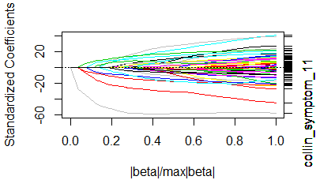

```r
plot(final_enet, use.color = TRUE)
```

```
Ignoring unknown aesthetics: shape
```

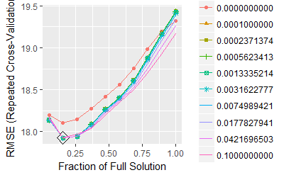

```r
ggplot(enet_model, highlight = TRUE)
```

We can see from the graph that the main responsible of the performance variation is the `fraction` parameter, while the parameter `lambda` yields linear translation of the curve driven by the `fraction`.

Moreover, we can see again that the parameters chosen in automatic by `caret` are sub-optimal, i.e. the chosen couple of `fraction`-`lambda` is a point on the (left) border of the graph. On the other hand, the `fraction`-point of best performance seams to be identified (near 0.1), so we can focus on a range of `fraction`s around this point.

With regard to the `lambda` parameter, its behaviour is not very clear: the curve of `lambda` = 0 has a curvature quite different from the other; however, it appears that the performance improves as the value increases! Hence, for the parameter `lambda` we can search more values in a wider range close to 1, but still considering `lambda` = 0, i.e. the LASSO.

```r
message()
```

```r
message('Elapsed time: ', enet2_time['elapsed'] %>% round(3), ' seconds')
```

```
Elapsed time: 638 seconds
```

```r
message('Used memory: ',
        format(enet2_mem/(2^20), digits = 3, scientific = FALSE),
        ' MB')
```

```
Used memory: 0.951 MB
```

```r
enet2_rmse <- (predict(enet2_model, test_glm[-1]) - test_glm[[1]])^2 %>%
    mean %>%
    sqrt
message('Test rmse: ', enet2_rmse)
```

```
Test rmse: 17.0143233017094
```

```r
final_enet2_param <- enet2_model$finalModel$tuneValue
message('Final tuned parameter is: ',
        names(final_enet2_param)[[1]], ' = ',
        final_enet2_param[[1]] %>% round(3),
        '\n',
        names(final_enet2_param)[[2]], ' = ',
        final_enet2_param[[2]] %>% round(3)
)
```

```
Final tuned parameter is: fraction = 0.062
lambda = 0.045
```

```r
final_enet2 <- enet2_model$finalModel
enet2_best_beta <- predict(final_enet2,
        s    = final_enet2_param[[1]],
        mode = 'fraction',
        type = 'coefficients'
    )$coefficients %>%
    `[`(. != 0) %>%
    round(3)
message('The variables used by the best (up to one SE) elastic network
        machine, with the corresponding beta values, are:\n',
        paste(enet2_best_beta, names(enet2_best_beta),
              sep = '\t= ',
              collapse = '\n'
        )
)
```

```
The variables used by the best (up to one SE) elastic network
        machine, with the corresponding beta values, are:
-2.195  = collin_symptom_11
-0.349  = height
-0.246  = symptom_3_N
0.246   = symptom_3_Y
```

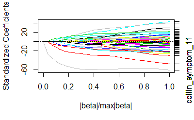

```r
plot(final_enet2, xvar = 'fraction', use.color = TRUE)
```

[figure not shown]

```r
ggplot(enet2_model, highlight = TRUE)
```

```r
message()
```

```r
message('Elapsed time: ', enet3_time['elapsed'] %>% round(3), ' seconds')
```

```
Elapsed time: 1904.14 seconds
```

```r
message('Used memory: ',
        format(enet3_mem/(2^20), digits = 3, scientific = FALSE),
        ' MB')
```

```
Used memory: 3.04 MB
```

```r
enet3_rmse <- (predict(enet3_model, test_glm[-1]) - test_glm[[1]])^2 %>%
    mean %>%
    sqrt
message('Test rmse: ', enet3_rmse)
```

```
Test rmse: 17.0190941537147
```

```r
final_enet3_param <- enet3_model$finalModel$tuneValue
message('Final tuned parameter is: ',
        names(final_enet3_param)[[1]], ' = ',
        final_enet3_param[[1]] %>% round(3),
        '\n',
        names(final_enet3_param)[[2]], ' = ',
        final_enet3_param[[2]]
)
```

```
Final tuned parameter is: fraction = 0.058
lambda = 1e-05
```

```r
final_enet3 <- enet3_model$finalModel
enet3_best_beta <- predict(final_enet3,
        s    = final_enet3_param[[1]],
        mode = 'fraction',
        type = 'coefficients'
    )$coefficients %>%
    `[`(. != 0) %>%
    round(3)
message('The variables used by the best (up to one SE) elastic network
        machine, with the corresponding beta values, are:\n',
        paste(enet3_best_beta, names(enet3_best_beta),
              sep = '\t= ',
              collapse = '\n'
        )
)
```

```
The variables used by the best (up to one SE) elastic network
        machine, with the corresponding beta values, are:
-2.194  = collin_symptom_11
-0.307  = height
-0.234  = symptom_3_N
0.234   = symptom_3_Y
```

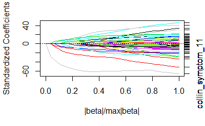

```r
plot(final_enet3, xvar = 'fraction', use.color = TRUE)
```

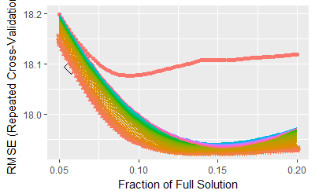

```r
ggplot(enet3_model, plotType = 'scatter', highlight = TRUE) +
    theme(legend.position="none")
```

Again, the `lambda` parameter lies on the border of the interval considered and. Hence, we decide to go furter on the investigation. This time, we can be confident in split the range of `lambda`s in two, i.e. a lower set aimed to find the optimal value for the final selection of the model and an upper one aimed to ifentify the best model over all the one observed. On the otehr hand, we hav just identify a adeguate range of value for `fraction` and so we will not change it.

```r
message()
```

```r
message('Elapsed time: ', enet4_time['elapsed'] %>% round(3), ' seconds')
```

```
Elapsed time: 1937.87 seconds
```

```r
message('Used memory: ',
        format(enet4_mem/(2^20), digits = 3, scientific = FALSE),
        ' MB')
```

```
Used memory: 2.85 MB
```

```r
enet4_rmse <- (predict(enet4_model, test_glm[-1]) - test_glm[[1]])^2 %>%
    mean %>%
    sqrt
message('Test rmse: ', enet4_rmse)
```

```
Test rmse: 17.0190941537147
```

```r
final_enet4_param <- enet4_model$finalModel$tuneValue
message('Final tuned parameter is: ',
        names(final_enet4_param)[[1]], ' = ',
        final_enet4_param[[1]] %>% round(3),
        '\n',
        names(final_enet4_param)[[2]], ' = ',
        final_enet4_param[[2]]
)
```

```
Final tuned parameter is: fraction = 0.058
lambda = 1e-05
```

```r
final_enet4 <- enet4_model$finalModel
enet4_best_beta <- predict(final_enet4,
        s    = final_enet4_param[[1]],
        mode = 'fraction',
        type = 'coefficients'
    )$coefficients %>%
    `[`(. != 0) %>%
    round(3)
message('The variables used by the best (up to one SE) elastic network
        machine, with the corresponding beta values, are:\n',
        paste(enet4_best_beta, names(enet4_best_beta),
              sep = '\t= ',
              collapse = '\n'
        )
)
```

```
The variables used by the best (up to one SE) elastic network
        machine, with the corresponding beta values, are:
-2.194  = collin_symptom_11
-0.307  = height
-0.234  = symptom_3_N
0.234   = symptom_3_Y
```

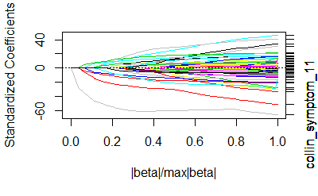

```r
plot(final_enet4, xvar = 'fraction', use.color = TRUE)
```

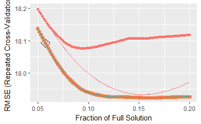

```r
ggplot(enet4_model, plotType = 'scatter', highlight = TRUE) +
    theme(legend.position="none")
```

### CART

Now, we will continue using tree-based algorithm, hence we movre from the pre-processed data to the original one.

```r
message()
```

```r
message('Elapsed time: ', cart_time['elapsed'] %>% round(3), ' seconds')
```

```
Elapsed time: 133.83 seconds
```

```r
message('Used memory: ',
        format(cart_mem/(2^20), digits = 3, scientific = FALSE),
        ' MB')
```

```
Used memory: 1.36 MB
```

```r
cart_rmse <- (predict(cart_model, test_tree[-1]) - test_tree[[1]])^2 %>%
    mean %>%
    sqrt
message('Test rmse: ', cart_rmse)
```

```
Test rmse: 15.9740657584917
```

```r
final_cart_param <- cart_model$finalModel$tuneValue
message('Final tuned parameter is: ',
        names(final_cart_param)[[1]], ' = ',
        final_cart_param[[1]] %>% round(3)
)
```

```
Final tuned parameter is: cp = 0.069
```

```r
final_cart <- cart_model$finalModel
cart_best_split_label <- labels(final_cart,
        digits = 3L,
        minlength = 0L
    ) %>%
    str_subset('[^root]')
cart_best_split <- data_frame(
    variable  = cart_best_split_label %>% str_extract('\\w+'),
    direction = cart_best_split_label %>% str_extract('\\W+'),
    cutoff    = cart_best_split_label %>% str_extract('\\w+$')
)
message('The variables used by the best (up to one SE) CART machine are:\n',
        paste(cart_best_split_label, collapse = '\n')
)
```

```
The variables used by the best (up to one SE) CART machine are:
collin_symptom_11>=1.26e+06
collin_symptom_11< 1.26e+06
symptom_12< 65.5
symptom_12>=65.5
```

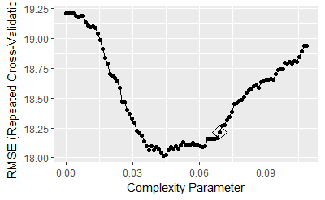

```r
ggplot(cart_model, highlight = TRUE)
```

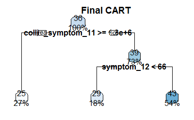

```r
rpart.plot(final_cart)
title("Final CART")
```

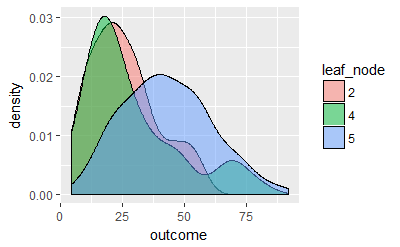

```r
train_tree %>%
    dplyr::select(outcome) %>%
    bind_cols(final_cart$where %>% data_frame(leaf_node = factor(.))) %>%
    ggplot(aes(outcome, fill = leaf_node)) +
    geom_density(alpha = 0.5)
```

```r
message()
```

```r
message('Elapsed time: ', cart2_time['elapsed'] %>% round(3), ' seconds')
```

```
Elapsed time: 134.34 seconds
```

```r
message('Used memory: ',
        format(cart2_mem/(2^20), digits = 3, scientific = FALSE),
        ' MB')
```

```
Used memory: 0.911 MB
```

```r
cart2_rmse <- (predict(cart2_model, test_tree[-1]) - test_tree[[1]])^2 %>%
    mean %>%
    sqrt
message('Test rmse: ', cart2_rmse)
```

```
Test rmse: 15.9740657584917
```

```r
final_cart2_param <- cart2_model$finalModel$tuneValue
message('Final tuned parameter is: ',
        names(final_cart2_param)[[1]], ' = ',
        final_cart2_param[[1]] %>% round(3)
)
```

```
Final tuned parameter is: cp = 0.068
```

```r
final_cart2 <- cart2_model$finalModel
cart2_best_split_label <- labels(final_cart2,
        digits = 3L,
        minlength = 0L
    ) %>%
    str_subset('[^root]')
cart2_best_split <- data_frame(
    variable  = cart2_best_split_label %>% str_extract('\\w+'),
    direction = cart2_best_split_label %>% str_extract('\\W+'),
    cutoff    = cart2_best_split_label %>% str_extract('\\w+$')
)
message('The variables used by the best (up to one SE) CART machine are:\n',
        paste(cart2_best_split_label, collapse = '\n')
)
```

```
The variables used by the best (up to one SE) CART machine are:
collin_symptom_11>=1.26e+06
collin_symptom_11< 1.26e+06
symptom_12< 65.5
symptom_12>=65.5
```

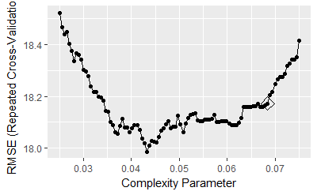

```r
ggplot(cart2_model, highlight = TRUE)
```

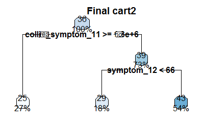

```r
rpart.plot(final_cart2)
title("Final cart2")
```

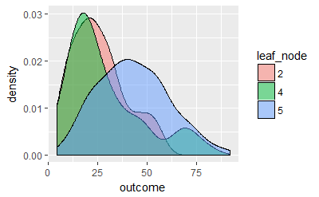

```r
train_tree %>%
    dplyr::select(outcome) %>%
    bind_cols(final_cart2$where %>% data_frame(leaf_node = factor(.))) %>%
    ggplot(aes(outcome, fill = leaf_node)) +
    geom_density(alpha = 0.5)
```

The selected `cp` moved back to the left, meaning that there is some granularity in a way to improve the selection. Run a last refinement of the model to find a simpler model, within one SE from the best.

```r
message()
```

```r
message('Elapsed time: ', cart3_time['elapsed'] %>% round(3), ' seconds')
```

```
Elapsed time: 132.5 seconds
```

```r
message('Used memory: ',
        format(cart3_mem/(2^20), digits = 3, scientific = FALSE),
        ' MB')
```

```
Used memory: 0.911 MB
```

```r
cart3_rmse <- (predict(cart3_model, test_tree[-1]) - test_tree[[1]])^2 %>%
    mean %>%
    sqrt
message('Test rmse: ', cart3_rmse)
```

```
Test rmse: 14.9893763149395
```

```r
final_cart3_param <- cart3_model$finalModel$tuneValue
message('Final tuned parameter is: ',
        names(final_cart3_param)[[1]], ' = ',
        final_cart3_param[[1]] %>% round(3)
)
```

```
Final tuned parameter is: cp = 0.05
```

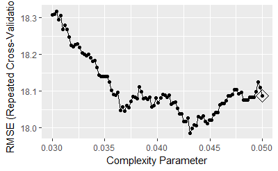

```r
ggplot(cart3_model, highlight = TRUE)
```

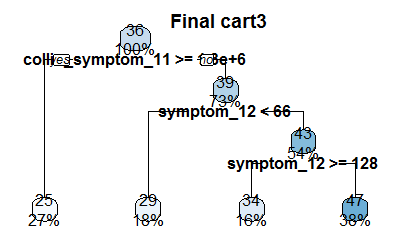

```r
final_cart3 <- cart3_model$finalModel
rpart.plot(final_cart3)
title("Final cart3")
```

```r
cart3_best_split_label <- labels(final_cart3,
        digits = 3L,
        minlength = 0L
    ) %>%
    str_subset('[^root]')
cart3_best_split <- data_frame(
    variable  = cart3_best_split_label %>% str_extract('\\w+'),
    direction = cart3_best_split_label %>% str_extract('\\W+'),
    cutoff    = cart3_best_split_label %>% str_extract('\\w+$')
)
message('The variables used by the best (up to one SE) CART machine are:\n',
        paste(cart3_best_split_label, collapse = '\n')
)
```

```
The variables used by the best (up to one SE) CART machine are:
collin_symptom_11>=1.26e+06
collin_symptom_11< 1.26e+06
symptom_12< 65.5
symptom_12>=65.5
symptom_12>=128
symptom_12< 128
```

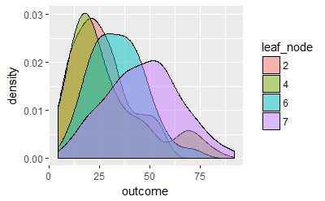

```r
train_tree %>%
    dplyr::select(outcome) %>%
    bind_cols(final_cart3$where %>% data_frame(leaf_node = factor(.))) %>%
    ggplot(aes(outcome, fill = leaf_node)) +
    geom_density(alpha = 0.5)
```

### Conditional tree

```r
message()
```

```r
message('Elapsed time: ', ctree_time['elapsed'] %>% round(3), ' seconds')
```

```
Elapsed time: 485.14 seconds
```

```r
message('Used memory: ',
        format(ctree_mem/(2^20), digits = 3, scientific = FALSE),
        ' MB')
```

```
Used memory: 11 MB
```

```r
ctree_rmse <- (predict(ctree_model, test_tree[-1]) - test_tree[[1]])^2 %>%
    mean %>%
    sqrt
message('Test rmse: ', ctree_rmse)
```

```
Test rmse: 17.2948756270807
```

```r
final_ctree_param <- ctree_model$bestTune
message('Final tuned parameter is: ',
        names(final_ctree_param)[[1]], ' = ',
        final_ctree_param[[1]] %>% round(3)
)
```

```
Final tuned parameter is: mincriterion = 0.99
```

```r
final_ctree <- ctree_model$finalModel
ctree_best_split_label <- labels(final_ctree,
        digits = 3L,
        minlength = 0L
    ) %>%
    str_subset('[^root]')
flat_ctree <- unlist(final_ctree@tree)
ctree_best_split <- unique(
    flat_ctree[grepl("*variableName",names(flat_ctree))]
)
message('The variables used by the best (up to one SE) CART machine are:\n',
        paste(ctree_best_split, collapse = '\n')
)
```

```
The variables used by the best (up to one SE) CART machine are:
collin_symptom_11
```

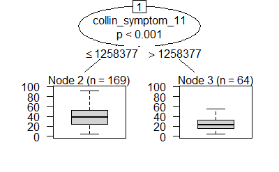

```r
plot(final_ctree)
```

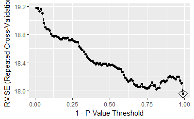

```r
ggplot(ctree_model, highlight = TRUE)
```

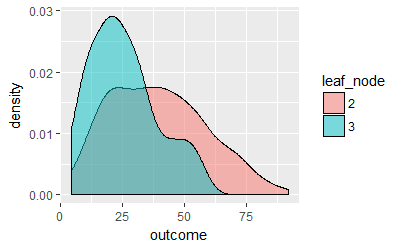

```r
train_tree %>%
    dplyr::select(outcome) %>%  # `ctree` is an S4 object, subsetted by "@"
    bind_cols(final_ctree@where %>% data_frame(leaf_node = factor(.))) %>%
    ggplot(aes(outcome, fill = leaf_node)) +
    geom_density(alpha = 0.5)
```

```r
gc(verbose = FALSE, reset = TRUE)
```

```
          used  (Mb) gc trigger  (Mb) max used  (Mb)
Ncells 2298794 122.8    3886542 207.6  2298794 122.8
Vcells 3866935  29.6   10991486  83.9  3866935  29.6
```

```r
ctree2_time <- system.time(
    ctree2_mem <- pryr::mem_change(
        ctree2_model <- train(
            x = train_tree[-1],
            y = train_tree[[1]],
            method     = "ctree",
            metric     = "RMSE",
            maximize   = FALSE,
            trControl  = trainControl(
                method            = 'repeatedcv',
                number            = n_folds,
                repeats           = n_reps,
                search            = "grid",
                selectionFunction = "oneSE",
                savePredictions   = "final",
                seeds             = caret_seeds
            ),
            tuneGrid   = expand.grid(
                mincriterion = seq(
                    from = .9,
                    to   = .95,
                    length.out = tune_length
                )
            )
        )
    )
)
message()
```

```r
message('Elapsed time: ', ctree2_time['elapsed'] %>% round(3), ' seconds')
```

```
Elapsed time: 468.75 seconds
```

```r
message('Used memory: ',
        format(ctree2_mem/(2^20), digits = 3, scientific = FALSE),
        ' MB')
```

```
Used memory: 1.03 MB
```

```r
ctree2_rmse <- (predict(ctree2_model, test_tree[-1]) - test_tree[[1]])^2 %>%
    mean %>%
    sqrt
message('Test rmse: ', ctree2_rmse)
```

```
Test rmse: 17.6720279442915
```

```r
final_ctree2_param <- ctree2_model$bestTune
message('Final tuned parameter is: ',
        names(final_ctree2_param)[[1]], ' = ',
        final_ctree2_param[[1]] %>% round(3)
)
```

```
Final tuned parameter is: mincriterion = 0.95
```

```r
final_ctree2 <- ctree2_model$finalModel
flat_ctree2 <- unlist(final_ctree2@tree)
ctree2_best_split <- unique(
    flat_ctree2[grepl("*variableName",names(flat_ctree2))]
)
message('The variables used by the best (up to one SE) CART machine are:\n',
        paste(ctree2_best_split, collapse = '\n')
)
```

```
The variables used by the best (up to one SE) CART machine are:
collin_symptom_11
symptom_4
```

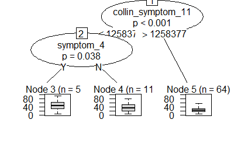

```r
plot(final_ctree2)
```

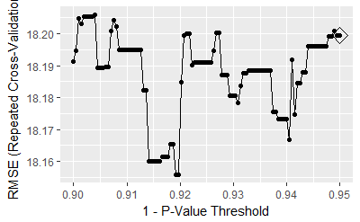

```r
ggplot(ctree2_model, highlight = TRUE)
```

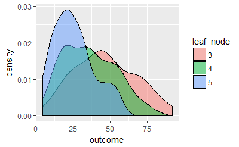

```r
train_tree %>%
    dplyr::select(outcome) %>%
    bind_cols(final_ctree2@where %>% data_frame(leaf_node = factor(.))) %>%
    ggplot(aes(outcome, fill = leaf_node)) +
    geom_density(alpha = 0.5)
```

The final model selected a `mincriterion` of 0.95 which is at the border of the graph and the upper limit selected by us. This, generally, leaves some space for improvement, but we have no interest to select a `mincriterion` above this threshold (mainly because the primary pourpose of this kind of tree is not the performance itself but a sort of a balance between the performance and the statistical interpretation).